# Results: RMST_validation.sas

The LIFETEST Procedure

Stratum 1: TBX_group = 0

| Product-Limit Survival Estimates dead_years | Product-Limit Survival Estimates | Product-Limit Survival Estimates Survival | Product-Limit Survival Estimates Failure | Product-Limit Survival Estimates Survival Standard Error | Product-Limit Survival Estimates Number Failed | Product-Limit Survival Estimates Number Left |
| --- | --- | --- | --- | --- | --- | --- |
| 0.0000 |  | 1.0000 | 0 | 0 | 0 | 57 |
| 0.1013 |  | 0.9825 | 0.0175 | 0.0174 | 1 | 56 |
| 0.4162 |  | 0.9649 | 0.0351 | 0.0244 | 2 | 55 |
| 0.5394 |  | . | . | . | 3 | 54 |
| 0.5394 |  | 0.9298 | 0.0702 | 0.0338 | 4 | 53 |
| 0.5996 |  | 0.9123 | 0.0877 | 0.0375 | 5 | 52 |
| 0.7091 |  | 0.8947 | 0.1053 | 0.0406 | 6 | 51 |
| 0.7830 |  | 0.8772 | 0.1228 | 0.0435 | 7 | 50 |
| 1.1389 |  | 0.8596 | 0.1404 | 0.0460 | 8 | 49 |
| 1.3169 |  | 0.8421 | 0.1579 | 0.0483 | 9 | 48 |
| 1.4757 |  | 0.8246 | 0.1754 | 0.0504 | 10 | 47 |
| 1.5195 | * | . | . | . | 10 | 46 |
| 1.5880 | * | . | . | . | 10 | 45 |
| 1.6564 | * | . | . | . | 10 | 44 |
| 1.7358 |  | 0.8058 | 0.1942 | 0.0526 | 11 | 43 |
| 1.8864 | * | . | . | . | 11 | 42 |
| 2.1437 |  | 0.7866 | 0.2134 | 0.0547 | 12 | 41 |
| 2.2423 | * | . | . | . | 12 | 40 |
| 2.2478 | * | . | . | . | 12 | 39 |
| 2.2642 | * | . | . | . | 12 | 38 |
| 2.3162 | * | . | . | . | 12 | 37 |
| 2.3600 | * | . | . | . | 12 | 36 |
| 2.4285 | * | . | . | . | 12 | 35 |
| 2.4805 | * | . | . | . | 12 | 34 |
| 2.4832 | * | . | . | . | 12 | 33 |
| 2.5818 | * | . | . | . | 12 | 32 |
| 2.6119 | * | . | . | . | 12 | 31 |
| 2.6393 | * | . | . | . | 12 | 30 |
| 2.6639 | * | . | . | . | 12 | 29 |
| 2.7379 | * | . | . | . | 12 | 28 |
| 2.7899 | * | . | . | . | 12 | 27 |
| 2.8036 | * | . | . | . | 12 | 26 |
| 2.8994 | * | . | . | . | 12 | 25 |
| 2.9131 | * | . | . | . | 12 | 24 |
| 3.1732 | * | . | . | . | 12 | 23 |
| 3.2799 |  | 0.7524 | 0.2476 | 0.0621 | 13 | 22 |
| 3.7262 |  | 0.7182 | 0.2818 | 0.0681 | 14 | 21 |
| 3.7947 |  | 0.6840 | 0.3160 | 0.0729 | 15 | 20 |
| 4.4983 |  | 0.6498 | 0.3502 | 0.0769 | 16 | 19 |
| 5.5414 | * | . | . | . | 16 | 18 |
| 5.7385 |  | 0.6137 | 0.3863 | 0.0806 | 17 | 17 |
| 6.4476 |  | 0.5776 | 0.4224 | 0.0836 | 18 | 16 |
| 6.6940 |  | 0.5415 | 0.4585 | 0.0858 | 19 | 15 |
| 8.4162 |  | 0.5054 | 0.4946 | 0.0873 | 20 | 14 |
| 9.1937 | * | . | . | . | 20 | 13 |
| 9.5222 | * | . | . | . | 20 | 12 |
| 9.7550 | * | . | . | . | 20 | 11 |
| 9.9466 |  | 0.4595 | 0.5405 | 0.0907 | 21 | 10 |
| 10.1930 | * | . | . | . | 21 | 9 |
| 10.2313 | * | . | . | . | 21 | 8 |
| 10.2724 | * | . | . | . | 21 | 7 |
| 10.3655 | * | . | . | . | 21 | 6 |
| 10.5708 | * | . | . | . | 21 | 5 |
| 10.6721 | * | . | . | . | 21 | 4 |
| 10.7598 | * | . | . | . | 21 | 3 |
| 10.9268 | * | . | . | . | 21 | 2 |
| 10.9322 | * | . | . | . | 21 | 1 |
| 10.9733 | * | . | . | . | 21 | 0 |

Note:The marked survival times are censored observations.

Summary Statistics for Time Variable dead_years

| Quartile Estimates Percent | Quartile Estimates Point Estimate | Quartile Estimates 95% Confidence Interval Transform | Quartile Estimates 95% Confidence Interval [Lower | Quartile Estimates 95% Confidence Interval Upper) |
| --- | --- | --- | --- | --- |
| 75 | . | LOGLOG | . | . |
| 50 | 9.9466 | LOGLOG | 4.4983 | . |
| 25 | 3.7262 | LOGLOG | 1.1389 | 5.7385 |

| Mean | Standard Error |
| --- | --- |
| 6.7433 | 0.5808 |

Note:The mean survival time and its standard error were underestimated because the largest observation was censored and the estimation was restricted to the largest event time.

The LIFETEST Procedure

Stratum 2: TBX_group = 1

| Product-Limit Survival Estimates dead_years | Product-Limit Survival Estimates | Product-Limit Survival Estimates Survival | Product-Limit Survival Estimates Failure | Product-Limit Survival Estimates Survival Standard Error | Product-Limit Survival Estimates Number Failed | Product-Limit Survival Estimates Number Left |
| --- | --- | --- | --- | --- | --- | --- |
| 0.0000 |  | 1.0000 | 0 | 0 | 0 | 48 |
| 0.0602 |  | 0.9792 | 0.0208 | 0.0206 | 1 | 47 |
| 0.1259 |  | 0.9583 | 0.0417 | 0.0288 | 2 | 46 |
| 0.1451 |  | 0.9375 | 0.0625 | 0.0349 | 3 | 45 |
| 0.2355 |  | 0.9167 | 0.0833 | 0.0399 | 4 | 44 |
| 0.3751 |  | 0.8958 | 0.1042 | 0.0441 | 5 | 43 |
| 0.4189 |  | 0.8750 | 0.1250 | 0.0477 | 6 | 42 |
| 0.4408 |  | 0.8542 | 0.1458 | 0.0509 | 7 | 41 |
| 0.6023 |  | 0.8333 | 0.1667 | 0.0538 | 8 | 40 |
| 0.8816 |  | 0.8125 | 0.1875 | 0.0563 | 9 | 39 |
| 0.9227 |  | 0.7917 | 0.2083 | 0.0586 | 10 | 38 |
| 0.9363 |  | 0.7708 | 0.2292 | 0.0607 | 11 | 37 |
| 1.3744 | * | . | . | . | 11 | 36 |
| 1.4401 |  | 0.7494 | 0.2506 | 0.0626 | 12 | 35 |
| 1.4456 |  | 0.7280 | 0.2720 | 0.0644 | 13 | 34 |
| 1.5086 |  | 0.7066 | 0.2934 | 0.0660 | 14 | 33 |
| 1.5195 |  | 0.6852 | 0.3148 | 0.0674 | 15 | 32 |
| 1.6044 | * | . | . | . | 15 | 31 |
| 1.8590 | * | . | . | . | 15 | 30 |
| 2.0862 |  | 0.6623 | 0.3377 | 0.0689 | 16 | 29 |
| 2.1711 |  | 0.6395 | 0.3605 | 0.0702 | 17 | 28 |
| 2.2012 |  | 0.6167 | 0.3833 | 0.0713 | 18 | 27 |
| 2.3190 | * | . | . | . | 18 | 26 |
| 2.3819 | * | . | . | . | 18 | 25 |
| 2.3956 | * | . | . | . | 18 | 24 |
| 2.4175 | * | . | . | . | 18 | 23 |
| 2.4504 | * | . | . | . | 18 | 22 |
| 2.4723 | * | . | . | . | 18 | 21 |
| 2.6612 | * | . | . | . | 18 | 20 |
| 2.6858 |  | 0.5858 | 0.4142 | 0.0741 | 19 | 19 |
| 2.7817 | * | . | . | . | 19 | 18 |
| 3.1841 |  | 0.5533 | 0.4467 | 0.0768 | 20 | 17 |
| 3.1978 |  | 0.5207 | 0.4793 | 0.0789 | 21 | 16 |
| 3.2444 |  | 0.4882 | 0.5118 | 0.0804 | 22 | 15 |
| 3.7837 |  | 0.4556 | 0.5444 | 0.0813 | 23 | 14 |
| 4.8022 |  | 0.4231 | 0.5769 | 0.0818 | 24 | 13 |
| 5.6838 |  | 0.3906 | 0.6094 | 0.0817 | 25 | 12 |
| 7.0445 |  | 0.3580 | 0.6420 | 0.0811 | 26 | 11 |
| 9.9329 | * | . | . | . | 26 | 10 |
| 9.9713 | * | . | . | . | 26 | 9 |
| 10.0397 | * | . | . | . | 26 | 8 |
| 10.2834 | * | . | . | . | 26 | 7 |
| 10.4367 | * | . | . | . | 26 | 6 |
| 10.6557 | * | . | . | . | 26 | 5 |
| 10.6749 | * | . | . | . | 26 | 4 |
| 10.8309 | * | . | . | . | 26 | 3 |
| 10.9487 | * | . | . | . | 26 | 2 |
| 10.9487 | * | . | . | . | 26 | 1 |
| 10.9596 | * | . | . | . | 26 | 0 |

Note:The marked survival times are censored observations.

Summary Statistics for Time Variable dead_years

| Quartile Estimates Percent | Quartile Estimates Point Estimate | Quartile Estimates 95% Confidence Interval Transform | Quartile Estimates 95% Confidence Interval [Lower | Quartile Estimates 95% Confidence Interval Upper) |
| --- | --- | --- | --- | --- |
| 75 | . | LOGLOG | 5.6838 | . |
| 50 | 3.2444 | LOGLOG | 2.1711 | . |
| 25 | 1.4401 | LOGLOG | 0.4189 | 2.2012 |

| Mean | Standard Error |
| --- | --- |
| 3.9931 | 0.4308 |

Note:The mean survival time and its standard error were underestimated because the largest observation was censored and the estimation was restricted to the largest event time.

| Summary of the Number of Censored and Uncensored Values Stratum | Summary of the Number of Censored and Uncensored Values TBX_group | Summary of the Number of Censored and Uncensored Values Total | Summary of the Number of Censored and Uncensored Values Failed | Summary of the Number of Censored and Uncensored Values Censored | Summary of the Number of Censored and Uncensored Values Percent Censored |
| --- | --- | --- | --- | --- | --- |
| 1 | 0 | 57 | 21 | 36 | 63.16 |
| 2 | 1 | 48 | 26 | 22 | 45.83 |
| Total |  | 105 | 47 | 58 | 55.24 |

Note:5 observations with invalid time, censoring, or strata values were deleted.

The LIFETEST Procedure

Testing Homogeneity of Survival Curves for dead_years over Strata

| Rank Statistics TBX_group | Rank Statistics Log-Rank | Rank Statistics Wilcoxon |
| --- | --- | --- |
| 0 | -5.9201 | -502.00 |
| 1 | 5.9201 | 502.00 |

| Covariance Matrix for the Log-Rank Statistics TBX_group | Covariance Matrix for the Log-Rank Statistics 0 | Covariance Matrix for the Log-Rank Statistics 1 |
| --- | --- | --- |
| 0 | 11.4825 | -11.4825 |
| 1 | -11.4825 | 11.4825 |

| Covariance Matrix for the Wilcoxon Statistics TBX_group | Covariance Matrix for the Wilcoxon Statistics 0 | Covariance Matrix for the Wilcoxon Statistics 1 |
| --- | --- | --- |
| 0 | 64342.5 | -64342.5 |
| 1 | -64342.5 | 64342.5 |

| Test of Equality over Strata Test | Test of Equality over Strata Chi-Square | Test of Equality over Strata DF | Test of Equality over Strata Pr > Chi-Square |
| --- | --- | --- | --- |
| Log-Rank | 3.0522 | 1 | 0.0806 |
| Wilcoxon | 3.9166 | 1 | 0.0478 |
| -2Log(LR) | 3.0255 | 1 | 0.0820 |

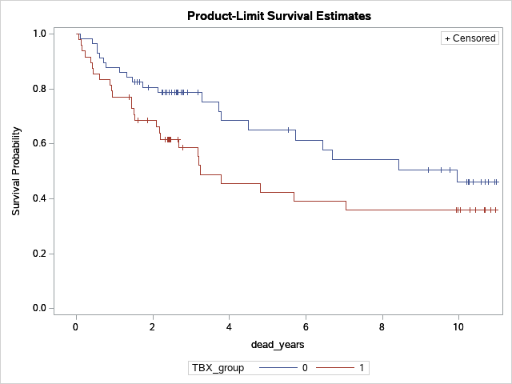

The LIFETEST Procedure

Stratum 1: TBX_group = 0

| Product-Limit Survival Estimates event_free_years | Product-Limit Survival Estimates | Product-Limit Survival Estimates Survival | Product-Limit Survival Estimates Failure | Product-Limit Survival Estimates Survival Standard Error | Product-Limit Survival Estimates Number Failed | Product-Limit Survival Estimates Number Left |
| --- | --- | --- | --- | --- | --- | --- |
| 0.0000 |  | 1.0000 | 0 | 0 | 0 | 57 |
| 0.0274 |  | 0.9825 | 0.0175 | 0.0174 | 1 | 56 |
| 0.0301 |  | 0.9649 | 0.0351 | 0.0244 | 2 | 55 |
| 0.0438 |  | 0.9474 | 0.0526 | 0.0296 | 3 | 54 |
| 0.1013 |  | 0.9298 | 0.0702 | 0.0338 | 4 | 53 |
| 0.3669 |  | 0.9123 | 0.0877 | 0.0375 | 5 | 52 |
| 0.4162 |  | 0.8947 | 0.1053 | 0.0406 | 6 | 51 |
| 0.5394 |  | . | . | . | 7 | 50 |
| 0.5394 |  | 0.8596 | 0.1404 | 0.0460 | 8 | 49 |
| 0.7091 |  | 0.8421 | 0.1579 | 0.0483 | 9 | 48 |
| 0.7830 |  | 0.8246 | 0.1754 | 0.0504 | 10 | 47 |
| 1.1389 |  | 0.8070 | 0.1930 | 0.0523 | 11 | 46 |
| 1.3169 |  | 0.7895 | 0.2105 | 0.0540 | 12 | 45 |
| 1.4757 |  | 0.7719 | 0.2281 | 0.0556 | 13 | 44 |
| 1.5195 | * | . | . | . | 13 | 43 |
| 1.5880 | * | . | . | . | 13 | 42 |
| 1.6564 | * | . | . | . | 13 | 41 |
| 1.7358 |  | 0.7531 | 0.2469 | 0.0573 | 14 | 40 |
| 1.8864 | * | . | . | . | 14 | 39 |
| 2.1437 |  | 0.7338 | 0.2662 | 0.0590 | 15 | 38 |
| 2.2423 | * | . | . | . | 15 | 37 |
| 2.2478 | * | . | . | . | 15 | 36 |
| 2.2642 | * | . | . | . | 15 | 35 |
| 2.3162 | * | . | . | . | 15 | 34 |
| 2.3600 | * | . | . | . | 15 | 33 |
| 2.4285 | * | . | . | . | 15 | 32 |
| 2.4805 | * | . | . | . | 15 | 31 |
| 2.4832 | * | . | . | . | 15 | 30 |
| 2.5818 | * | . | . | . | 15 | 29 |
| 2.6119 | * | . | . | . | 15 | 28 |
| 2.6393 | * | . | . | . | 15 | 27 |
| 2.6639 | * | . | . | . | 15 | 26 |
| 2.7379 | * | . | . | . | 15 | 25 |
| 2.7899 | * | . | . | . | 15 | 24 |
| 2.8036 | * | . | . | . | 15 | 23 |
| 2.8994 | * | . | . | . | 15 | 22 |
| 2.9131 | * | . | . | . | 15 | 21 |
| 3.1732 | * | . | . | . | 15 | 20 |
| 3.2799 |  | 0.6971 | 0.3029 | 0.0665 | 16 | 19 |
| 3.7262 |  | 0.6604 | 0.3396 | 0.0724 | 17 | 18 |
| 3.7947 |  | 0.6237 | 0.3763 | 0.0771 | 18 | 17 |
| 4.1369 |  | 0.5870 | 0.4130 | 0.0808 | 19 | 16 |
| 4.4983 |  | 0.5503 | 0.4497 | 0.0837 | 20 | 15 |
| 5.5414 | * | . | . | . | 20 | 14 |
| 5.7385 |  | 0.5110 | 0.4890 | 0.0865 | 21 | 13 |
| 6.4476 |  | 0.4717 | 0.5283 | 0.0883 | 22 | 12 |
| 8.4162 |  | 0.4324 | 0.5676 | 0.0893 | 23 | 11 |
| 9.1937 | * | . | . | . | 23 | 10 |
| 9.5222 | * | . | . | . | 23 | 9 |
| 9.7550 | * | . | . | . | 23 | 8 |
| 9.9466 |  | 0.3784 | 0.6216 | 0.0930 | 24 | 7 |
| 10.1930 | * | . | . | . | 24 | 6 |
| 10.3655 | * | . | . | . | 24 | 5 |
| 10.5708 | * | . | . | . | 24 | 4 |
| 10.6721 | * | . | . | . | 24 | 3 |
| 10.9268 | * | . | . | . | 24 | 2 |
| 10.9322 | * | . | . | . | 24 | 1 |
| 10.9733 | * | . | . | . | 24 | 0 |

Note:The marked survival times are censored observations.

Summary Statistics for Time Variable event_free_years

| Quartile Estimates Percent | Quartile Estimates Point Estimate | Quartile Estimates 95% Confidence Interval Transform | Quartile Estimates 95% Confidence Interval [Lower | Quartile Estimates 95% Confidence Interval Upper) |
| --- | --- | --- | --- | --- |
| 75 | . | LOGLOG | 9.9466 | . |
| 50 | 6.4476 | LOGLOG | 3.7262 | . |
| 25 | 2.1437 | LOGLOG | 0.5394 | 4.1369 |

| Mean | Standard Error |
| --- | --- |
| 6.0295 | 0.6203 |

Note:The mean survival time and its standard error were underestimated because the largest observation was censored and the estimation was restricted to the largest event time.

The LIFETEST Procedure

Stratum 2: TBX_group = 1

| Product-Limit Survival Estimates event_free_years | Product-Limit Survival Estimates | Product-Limit Survival Estimates Survival | Product-Limit Survival Estimates Failure | Product-Limit Survival Estimates Survival Standard Error | Product-Limit Survival Estimates Number Failed | Product-Limit Survival Estimates Number Left |
| --- | --- | --- | --- | --- | --- | --- |
| 0.0000 |  | 1.0000 | 0 | 0 | 0 | 48 |
| 0.0055 |  | 0.9792 | 0.0208 | 0.0206 | 1 | 47 |
| 0.0164 |  | 0.9583 | 0.0417 | 0.0288 | 2 | 46 |
| 0.0575 |  | 0.9375 | 0.0625 | 0.0349 | 3 | 45 |
| 0.0602 |  | 0.9167 | 0.0833 | 0.0399 | 4 | 44 |
| 0.1259 |  | 0.8958 | 0.1042 | 0.0441 | 5 | 43 |
| 0.1451 |  | 0.8750 | 0.1250 | 0.0477 | 6 | 42 |
| 0.2355 |  | 0.8542 | 0.1458 | 0.0509 | 7 | 41 |
| 0.3751 |  | 0.8333 | 0.1667 | 0.0538 | 8 | 40 |
| 0.4189 |  | 0.8125 | 0.1875 | 0.0563 | 9 | 39 |
| 0.4408 |  | 0.7917 | 0.2083 | 0.0586 | 10 | 38 |
| 0.6023 |  | 0.7708 | 0.2292 | 0.0607 | 11 | 37 |
| 0.8816 |  | 0.7500 | 0.2500 | 0.0625 | 12 | 36 |
| 0.9227 |  | 0.7292 | 0.2708 | 0.0641 | 13 | 35 |
| 0.9363 |  | 0.7083 | 0.2917 | 0.0656 | 14 | 34 |
| 1.3744 | * | . | . | . | 14 | 33 |
| 1.4401 |  | 0.6869 | 0.3131 | 0.0670 | 15 | 32 |
| 1.4456 |  | 0.6654 | 0.3346 | 0.0683 | 16 | 31 |
| 1.5086 |  | 0.6439 | 0.3561 | 0.0694 | 17 | 30 |
| 1.5195 |  | 0.6225 | 0.3775 | 0.0703 | 18 | 29 |
| 1.6044 | * | . | . | . | 18 | 28 |
| 1.8590 | * | . | . | . | 18 | 27 |
| 2.0862 |  | 0.5994 | 0.4006 | 0.0714 | 19 | 26 |
| 2.1711 |  | 0.5764 | 0.4236 | 0.0723 | 20 | 25 |
| 2.2012 |  | 0.5533 | 0.4467 | 0.0730 | 21 | 24 |
| 2.3190 | * | . | . | . | 21 | 23 |
| 2.3819 | * | . | . | . | 21 | 22 |
| 2.3956 | * | . | . | . | 21 | 21 |
| 2.4175 | * | . | . | . | 21 | 20 |
| 2.4504 | * | . | . | . | 21 | 19 |
| 2.4723 | * | . | . | . | 21 | 18 |
| 2.6612 | * | . | . | . | 21 | 17 |
| 2.7159 |  | 0.5208 | 0.4792 | 0.0756 | 22 | 16 |
| 2.7817 | * | . | . | . | 22 | 15 |
| 3.1978 |  | 0.4860 | 0.5140 | 0.0781 | 23 | 14 |
| 3.2444 |  | 0.4513 | 0.5487 | 0.0799 | 24 | 13 |
| 3.7837 |  | 0.4166 | 0.5834 | 0.0809 | 25 | 12 |
| 4.8022 |  | 0.3819 | 0.6181 | 0.0813 | 26 | 11 |
| 5.6838 |  | 0.3472 | 0.6528 | 0.0810 | 27 | 10 |
| 7.0445 |  | 0.3125 | 0.6875 | 0.0800 | 28 | 9 |
| 10.0397 | * | . | . | . | 28 | 8 |
| 10.2834 | * | . | . | . | 28 | 7 |
| 10.4367 | * | . | . | . | 28 | 6 |
| 10.6557 | * | . | . | . | 28 | 5 |
| 10.6749 | * | . | . | . | 28 | 4 |
| 10.8939 |  | 0.2343 | 0.7657 | 0.0904 | 29 | 3 |
| 10.9487 | * | . | . | . | 29 | 2 |
| 10.9487 | * | . | . | . | 29 | 1 |
| 10.9596 | * | . | . | . | 29 | 0 |

Note:The marked survival times are censored observations.

Summary Statistics for Time Variable event_free_years

| Quartile Estimates Percent | Quartile Estimates Point Estimate | Quartile Estimates 95% Confidence Interval Transform | Quartile Estimates 95% Confidence Interval [Lower | Quartile Estimates 95% Confidence Interval Upper) |
| --- | --- | --- | --- | --- |
| 75 | 10.8939 | LOGLOG | 4.8022 | . |
| 50 | 3.1978 | LOGLOG | 1.5086 | 7.0445 |
| 25 | 0.9021 | LOGLOG | 0.1451 | 1.5195 |

| Mean | Standard Error |
| --- | --- |
| 4.8406 | 0.7157 |

Note:The mean survival time and its standard error were underestimated because the largest observation was censored and the estimation was restricted to the largest event time.

| Summary of the Number of Censored and Uncensored Values Stratum | Summary of the Number of Censored and Uncensored Values TBX_group | Summary of the Number of Censored and Uncensored Values Total | Summary of the Number of Censored and Uncensored Values Failed | Summary of the Number of Censored and Uncensored Values Censored | Summary of the Number of Censored and Uncensored Values Percent Censored |
| --- | --- | --- | --- | --- | --- |
| 1 | 0 | 57 | 24 | 33 | 57.89 |
| 2 | 1 | 48 | 29 | 19 | 39.58 |
| Total |  | 105 | 53 | 52 | 49.52 |

Note:5 observations with invalid time, censoring, or strata values were deleted.

The LIFETEST Procedure

Testing Homogeneity of Survival Curves for event_free_years over Strata

| Rank Statistics TBX_group | Rank Statistics Log-Rank | Rank Statistics Wilcoxon |
| --- | --- | --- |
| 0 | -6.0433 | -480.00 |
| 1 | 6.0433 | 480.00 |

| Covariance Matrix for the Log-Rank Statistics TBX_group | Covariance Matrix for the Log-Rank Statistics 0 | Covariance Matrix for the Log-Rank Statistics 1 |
| --- | --- | --- |
| 0 | 12.9611 | -12.9611 |
| 1 | -12.9611 | 12.9611 |

| Covariance Matrix for the Wilcoxon Statistics TBX_group | Covariance Matrix for the Wilcoxon Statistics 0 | Covariance Matrix for the Wilcoxon Statistics 1 |
| --- | --- | --- |
| 0 | 70653.0 | -70653.0 |
| 1 | -70653.0 | 70653.0 |

| Test of Equality over Strata Test | Test of Equality over Strata Chi-Square | Test of Equality over Strata DF | Test of Equality over Strata Pr > Chi-Square |
| --- | --- | --- | --- |
| Log-Rank | 2.8178 | 1 | 0.0932 |
| Wilcoxon | 3.2610 | 1 | 0.0709 |
| -2Log(LR) | 2.9173 | 1 | 0.0876 |

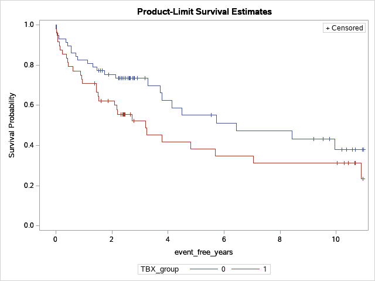

The LIFETEST Procedure

Stratum 1: EGFR_group = 0

| Product-Limit Survival Estimates dead_years | Product-Limit Survival Estimates | Product-Limit Survival Estimates Survival | Product-Limit Survival Estimates Failure | Product-Limit Survival Estimates Survival Standard Error | Product-Limit Survival Estimates Number Failed | Product-Limit Survival Estimates Number Left |
| --- | --- | --- | --- | --- | --- | --- |
| 0.0000 |  | 1.0000 | 0 | 0 | 0 | 35 |
| 0.5394 |  | 0.9714 | 0.0286 | 0.0282 | 1 | 34 |
| 0.5996 |  | 0.9429 | 0.0571 | 0.0392 | 2 | 33 |
| 1.3169 |  | 0.9143 | 0.0857 | 0.0473 | 3 | 32 |
| 1.5195 | * | . | . | . | 3 | 31 |
| 1.5880 | * | . | . | . | 3 | 30 |
| 1.6564 | * | . | . | . | 3 | 29 |
| 1.7358 |  | 0.8828 | 0.1172 | 0.0552 | 4 | 28 |
| 1.8864 | * | . | . | . | 4 | 27 |
| 2.2423 | * | . | . | . | 4 | 26 |
| 2.2478 | * | . | . | . | 4 | 25 |
| 2.2642 | * | . | . | . | 4 | 24 |
| 2.4832 | * | . | . | . | 4 | 23 |
| 2.7379 | * | . | . | . | 4 | 22 |
| 2.7899 | * | . | . | . | 4 | 21 |
| 2.8036 | * | . | . | . | 4 | 20 |
| 2.9131 | * | . | . | . | 4 | 19 |
| 3.7262 |  | 0.8363 | 0.1637 | 0.0691 | 5 | 18 |
| 3.7947 |  | 0.7898 | 0.2102 | 0.0794 | 6 | 17 |
| 4.4983 |  | 0.7434 | 0.2566 | 0.0873 | 7 | 16 |
| 5.5414 | * | . | . | . | 7 | 15 |
| 6.4476 |  | 0.6938 | 0.3062 | 0.0945 | 8 | 14 |
| 8.4162 |  | 0.6443 | 0.3557 | 0.0999 | 9 | 13 |
| 9.1937 | * | . | . | . | 9 | 12 |
| 9.5222 | * | . | . | . | 9 | 11 |
| 9.7550 | * | . | . | . | 9 | 10 |
| 9.9466 |  | 0.5798 | 0.4202 | 0.1087 | 10 | 9 |
| 10.0397 | * | . | . | . | 10 | 8 |
| 10.1930 | * | . | . | . | 10 | 7 |
| 10.3655 | * | . | . | . | 10 | 6 |
| 10.5708 | * | . | . | . | 10 | 5 |
| 10.6721 | * | . | . | . | 10 | 4 |
| 10.7598 | * | . | . | . | 10 | 3 |
| 10.9268 | * | . | . | . | 10 | 2 |
| 10.9322 | * | . | . | . | 10 | 1 |
| 10.9733 | * | . | . | . | 10 | 0 |

Note:The marked survival times are censored observations.

Summary Statistics for Time Variable dead_years

| Quartile Estimates Percent | Quartile Estimates Point Estimate | Quartile Estimates 95% Confidence Interval Transform | Quartile Estimates 95% Confidence Interval [Lower | Quartile Estimates 95% Confidence Interval Upper) |
| --- | --- | --- | --- | --- |
| 75 | . | LOGLOG | . | . |
| 50 | . | LOGLOG | 6.4476 | . |
| 25 | 4.4983 | LOGLOG | 1.7358 | . |

| Mean | Standard Error |
| --- | --- |
| 7.8281 | 0.6520 |

Note:The mean survival time and its standard error were underestimated because the largest observation was censored and the estimation was restricted to the largest event time.

The LIFETEST Procedure

Stratum 2: EGFR_group = 1

| Product-Limit Survival Estimates dead_years | Product-Limit Survival Estimates | Product-Limit Survival Estimates Survival | Product-Limit Survival Estimates Failure | Product-Limit Survival Estimates Survival Standard Error | Product-Limit Survival Estimates Number Failed | Product-Limit Survival Estimates Number Left |
| --- | --- | --- | --- | --- | --- | --- |
| 0.0000 |  | 1.0000 | 0 | 0 | 0 | 70 |
| 0.0602 |  | 0.9857 | 0.0143 | 0.0142 | 1 | 69 |
| 0.1013 |  | 0.9714 | 0.0286 | 0.0199 | 2 | 68 |
| 0.1259 |  | 0.9571 | 0.0429 | 0.0242 | 3 | 67 |
| 0.1451 |  | 0.9429 | 0.0571 | 0.0277 | 4 | 66 |
| 0.2355 |  | 0.9286 | 0.0714 | 0.0308 | 5 | 65 |
| 0.3751 |  | 0.9143 | 0.0857 | 0.0335 | 6 | 64 |
| 0.4162 |  | 0.9000 | 0.1000 | 0.0359 | 7 | 63 |
| 0.4189 |  | 0.8857 | 0.1143 | 0.0380 | 8 | 62 |
| 0.4408 |  | 0.8714 | 0.1286 | 0.0400 | 9 | 61 |
| 0.5394 |  | 0.8571 | 0.1429 | 0.0418 | 10 | 60 |
| 0.6023 |  | 0.8429 | 0.1571 | 0.0435 | 11 | 59 |
| 0.7091 |  | 0.8286 | 0.1714 | 0.0450 | 12 | 58 |
| 0.7830 |  | 0.8143 | 0.1857 | 0.0465 | 13 | 57 |
| 0.8816 |  | 0.8000 | 0.2000 | 0.0478 | 14 | 56 |
| 0.9227 |  | 0.7857 | 0.2143 | 0.0490 | 15 | 55 |
| 0.9363 |  | 0.7714 | 0.2286 | 0.0502 | 16 | 54 |
| 1.1389 |  | 0.7571 | 0.2429 | 0.0513 | 17 | 53 |
| 1.3744 | * | . | . | . | 17 | 52 |
| 1.4401 |  | 0.7426 | 0.2574 | 0.0523 | 18 | 51 |
| 1.4456 |  | 0.7280 | 0.2720 | 0.0533 | 19 | 50 |
| 1.4757 |  | 0.7135 | 0.2865 | 0.0541 | 20 | 49 |
| 1.5086 |  | 0.6989 | 0.3011 | 0.0550 | 21 | 48 |
| 1.5195 |  | 0.6843 | 0.3157 | 0.0557 | 22 | 47 |
| 1.6044 | * | . | . | . | 22 | 46 |
| 1.8590 | * | . | . | . | 22 | 45 |
| 2.0862 |  | 0.6691 | 0.3309 | 0.0565 | 23 | 44 |
| 2.1437 |  | 0.6539 | 0.3461 | 0.0572 | 24 | 43 |
| 2.1711 |  | 0.6387 | 0.3613 | 0.0579 | 25 | 42 |
| 2.2012 |  | 0.6235 | 0.3765 | 0.0585 | 26 | 41 |
| 2.3162 | * | . | . | . | 26 | 40 |
| 2.3190 | * | . | . | . | 26 | 39 |
| 2.3600 | * | . | . | . | 26 | 38 |
| 2.3819 | * | . | . | . | 26 | 37 |
| 2.3956 | * | . | . | . | 26 | 36 |
| 2.4175 | * | . | . | . | 26 | 35 |
| 2.4285 | * | . | . | . | 26 | 34 |
| 2.4504 | * | . | . | . | 26 | 33 |
| 2.4723 | * | . | . | . | 26 | 32 |
| 2.4805 | * | . | . | . | 26 | 31 |
| 2.5818 | * | . | . | . | 26 | 30 |
| 2.6119 | * | . | . | . | 26 | 29 |
| 2.6393 | * | . | . | . | 26 | 28 |
| 2.6612 | * | . | . | . | 26 | 27 |
| 2.6639 | * | . | . | . | 26 | 26 |
| 2.6858 |  | 0.5995 | 0.4005 | 0.0609 | 27 | 25 |
| 2.7817 | * | . | . | . | 27 | 24 |
| 2.8994 | * | . | . | . | 27 | 23 |
| 3.1732 | * | . | . | . | 27 | 22 |
| 3.1841 |  | 0.5723 | 0.4277 | 0.0640 | 28 | 21 |
| 3.1978 |  | 0.5450 | 0.4550 | 0.0665 | 29 | 20 |
| 3.2444 |  | 0.5178 | 0.4822 | 0.0685 | 30 | 19 |
| 3.2799 |  | 0.4905 | 0.5095 | 0.0701 | 31 | 18 |
| 3.7837 |  | 0.4633 | 0.5367 | 0.0713 | 32 | 17 |
| 4.8022 |  | 0.4360 | 0.5640 | 0.0721 | 33 | 16 |
| 5.6838 |  | 0.4088 | 0.5912 | 0.0726 | 34 | 15 |
| 5.7385 |  | 0.3815 | 0.6185 | 0.0727 | 35 | 14 |
| 6.6940 |  | 0.3543 | 0.6457 | 0.0724 | 36 | 13 |
| 7.0445 |  | 0.3270 | 0.6730 | 0.0718 | 37 | 12 |
| 9.9329 | * | . | . | . | 37 | 11 |
| 9.9713 | * | . | . | . | 37 | 10 |
| 10.2313 | * | . | . | . | 37 | 9 |
| 10.2724 | * | . | . | . | 37 | 8 |
| 10.2834 | * | . | . | . | 37 | 7 |
| 10.4367 | * | . | . | . | 37 | 6 |
| 10.6557 | * | . | . | . | 37 | 5 |
| 10.6749 | * | . | . | . | 37 | 4 |
| 10.8309 | * | . | . | . | 37 | 3 |
| 10.9487 | * | . | . | . | 37 | 2 |
| 10.9487 | * | . | . | . | 37 | 1 |
| 10.9596 | * | . | . | . | 37 | 0 |

Note:The marked survival times are censored observations.

Summary Statistics for Time Variable dead_years

| Quartile Estimates Percent | Quartile Estimates Point Estimate | Quartile Estimates 95% Confidence Interval Transform | Quartile Estimates 95% Confidence Interval [Lower | Quartile Estimates 95% Confidence Interval Upper) |
| --- | --- | --- | --- | --- |
| 75 | . | LOGLOG | 5.7385 | . |
| 50 | 3.2799 | LOGLOG | 2.2012 | 6.6940 |
| 25 | 1.4401 | LOGLOG | 0.6023 | 2.1711 |

| Mean | Standard Error |
| --- | --- |
| 4.0040 | 0.3620 |

Note:The mean survival time and its standard error were underestimated because the largest observation was censored and the estimation was restricted to the largest event time.

| Summary of the Number of Censored and Uncensored Values Stratum | Summary of the Number of Censored and Uncensored Values EGFR_group | Summary of the Number of Censored and Uncensored Values Total | Summary of the Number of Censored and Uncensored Values Failed | Summary of the Number of Censored and Uncensored Values Censored | Summary of the Number of Censored and Uncensored Values Percent Censored |
| --- | --- | --- | --- | --- | --- |
| 1 | 0 | 35 | 10 | 25 | 71.43 |
| 2 | 1 | 70 | 37 | 33 | 47.14 |
| Total |  | 105 | 47 | 58 | 55.24 |

Note:5 observations with invalid time, censoring, or strata values were deleted.

The LIFETEST Procedure

Testing Homogeneity of Survival Curves for dead_years over Strata

| Rank Statistics EGFR_group | Rank Statistics Log-Rank | Rank Statistics Wilcoxon |
| --- | --- | --- |
| 0 | -9.4761 | -731.00 |
| 1 | 9.4761 | 731.00 |

| Covariance Matrix for the Log-Rank Statistics EGFR_group | Covariance Matrix for the Log-Rank Statistics 0 | Covariance Matrix for the Log-Rank Statistics 1 |
| --- | --- | --- |
| 0 | 11.2045 | -11.2045 |
| 1 | -11.2045 | 11.2045 |

| Covariance Matrix for the Wilcoxon Statistics EGFR_group | Covariance Matrix for the Wilcoxon Statistics 0 | Covariance Matrix for the Wilcoxon Statistics 1 |
| --- | --- | --- |
| 0 | 61023.1 | -61023.1 |
| 1 | -61023.1 | 61023.1 |

| Test of Equality over Strata Test | Test of Equality over Strata Chi-Square | Test of Equality over Strata DF | Test of Equality over Strata Pr > Chi-Square |
| --- | --- | --- | --- |
| Log-Rank | 8.0142 | 1 | 0.0046 |
| Wilcoxon | 8.7567 | 1 | 0.0031 |
| -2Log(LR) | 10.6981 | 1 | 0.0011 |

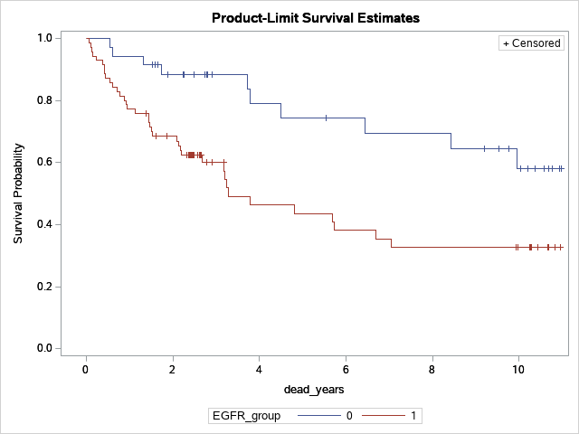

The LIFETEST Procedure

Stratum 1: EGFR_group = 0

| Product-Limit Survival Estimates event_free_years | Product-Limit Survival Estimates | Product-Limit Survival Estimates Survival | Product-Limit Survival Estimates Failure | Product-Limit Survival Estimates Survival Standard Error | Product-Limit Survival Estimates Number Failed | Product-Limit Survival Estimates Number Left |
| --- | --- | --- | --- | --- | --- | --- |
| 0.0000 |  | 1.0000 | 0 | 0 | 0 | 35 |
| 0.0301 |  | 0.9714 | 0.0286 | 0.0282 | 1 | 34 |
| 0.3669 |  | 0.9429 | 0.0571 | 0.0392 | 2 | 33 |
| 0.5394 |  | 0.9143 | 0.0857 | 0.0473 | 3 | 32 |
| 1.3169 |  | 0.8857 | 0.1143 | 0.0538 | 4 | 31 |
| 1.5195 | * | . | . | . | 4 | 30 |
| 1.5880 | * | . | . | . | 4 | 29 |
| 1.6564 | * | . | . | . | 4 | 28 |
| 1.7358 |  | 0.8541 | 0.1459 | 0.0604 | 5 | 27 |
| 1.8864 | * | . | . | . | 5 | 26 |
| 2.2423 | * | . | . | . | 5 | 25 |
| 2.2478 | * | . | . | . | 5 | 24 |
| 2.2642 | * | . | . | . | 5 | 23 |
| 2.4832 | * | . | . | . | 5 | 22 |
| 2.7379 | * | . | . | . | 5 | 21 |
| 2.7899 | * | . | . | . | 5 | 20 |
| 2.8036 | * | . | . | . | 5 | 19 |
| 2.9131 | * | . | . | . | 5 | 18 |
| 3.7262 |  | 0.8066 | 0.1934 | 0.0734 | 6 | 17 |
| 3.7947 |  | 0.7592 | 0.2408 | 0.0830 | 7 | 16 |
| 4.4983 |  | 0.7117 | 0.2883 | 0.0904 | 8 | 15 |
| 5.5414 | * | . | . | . | 8 | 14 |
| 6.4476 |  | 0.6609 | 0.3391 | 0.0972 | 9 | 13 |
| 8.4162 |  | 0.6101 | 0.3899 | 0.1021 | 10 | 12 |
| 9.1937 | * | . | . | . | 10 | 11 |
| 9.5222 | * | . | . | . | 10 | 10 |
| 9.7550 | * | . | . | . | 10 | 9 |
| 9.9466 |  | 0.5423 | 0.4577 | 0.1110 | 11 | 8 |
| 10.0397 | * | . | . | . | 11 | 7 |
| 10.1930 | * | . | . | . | 11 | 6 |
| 10.3655 | * | . | . | . | 11 | 5 |
| 10.5708 | * | . | . | . | 11 | 4 |
| 10.6721 | * | . | . | . | 11 | 3 |
| 10.9268 | * | . | . | . | 11 | 2 |
| 10.9322 | * | . | . | . | 11 | 1 |
| 10.9733 | * | . | . | . | 11 | 0 |

Note:The marked survival times are censored observations.

Summary Statistics for Time Variable event_free_years

| Quartile Estimates Percent | Quartile Estimates Point Estimate | Quartile Estimates 95% Confidence Interval Transform | Quartile Estimates 95% Confidence Interval [Lower | Quartile Estimates 95% Confidence Interval Upper) |
| --- | --- | --- | --- | --- |
| 75 | . | LOGLOG | . | . |
| 50 | . | LOGLOG | 4.4983 | . |
| 25 | 4.4983 | LOGLOG | 1.3169 | 9.9466 |

| Mean | Standard Error |
| --- | --- |
| 7.5132 | 0.6911 |

Note:The mean survival time and its standard error were underestimated because the largest observation was censored and the estimation was restricted to the largest event time.

The LIFETEST Procedure

Stratum 2: EGFR_group = 1

| Product-Limit Survival Estimates event_free_years | Product-Limit Survival Estimates | Product-Limit Survival Estimates Survival | Product-Limit Survival Estimates Failure | Product-Limit Survival Estimates Survival Standard Error | Product-Limit Survival Estimates Number Failed | Product-Limit Survival Estimates Number Left |
| --- | --- | --- | --- | --- | --- | --- |
| 0.0000 |  | 1.0000 | 0 | 0 | 0 | 70 |
| 0.0055 |  | 0.9857 | 0.0143 | 0.0142 | 1 | 69 |
| 0.0164 |  | 0.9714 | 0.0286 | 0.0199 | 2 | 68 |
| 0.0274 |  | 0.9571 | 0.0429 | 0.0242 | 3 | 67 |
| 0.0438 |  | 0.9429 | 0.0571 | 0.0277 | 4 | 66 |
| 0.0575 |  | 0.9286 | 0.0714 | 0.0308 | 5 | 65 |
| 0.0602 |  | 0.9143 | 0.0857 | 0.0335 | 6 | 64 |
| 0.1013 |  | 0.9000 | 0.1000 | 0.0359 | 7 | 63 |
| 0.1259 |  | 0.8857 | 0.1143 | 0.0380 | 8 | 62 |
| 0.1451 |  | 0.8714 | 0.1286 | 0.0400 | 9 | 61 |
| 0.2355 |  | 0.8571 | 0.1429 | 0.0418 | 10 | 60 |
| 0.3751 |  | 0.8429 | 0.1571 | 0.0435 | 11 | 59 |
| 0.4162 |  | 0.8286 | 0.1714 | 0.0450 | 12 | 58 |
| 0.4189 |  | 0.8143 | 0.1857 | 0.0465 | 13 | 57 |
| 0.4408 |  | 0.8000 | 0.2000 | 0.0478 | 14 | 56 |
| 0.5394 |  | 0.7857 | 0.2143 | 0.0490 | 15 | 55 |
| 0.6023 |  | 0.7714 | 0.2286 | 0.0502 | 16 | 54 |
| 0.7091 |  | 0.7571 | 0.2429 | 0.0513 | 17 | 53 |
| 0.7830 |  | 0.7429 | 0.2571 | 0.0522 | 18 | 52 |
| 0.8816 |  | 0.7286 | 0.2714 | 0.0532 | 19 | 51 |
| 0.9227 |  | 0.7143 | 0.2857 | 0.0540 | 20 | 50 |
| 0.9363 |  | 0.7000 | 0.3000 | 0.0548 | 21 | 49 |
| 1.1389 |  | 0.6857 | 0.3143 | 0.0555 | 22 | 48 |
| 1.3744 | * | . | . | . | 22 | 47 |
| 1.4401 |  | 0.6711 | 0.3289 | 0.0562 | 23 | 46 |
| 1.4456 |  | 0.6565 | 0.3435 | 0.0568 | 24 | 45 |
| 1.4757 |  | 0.6419 | 0.3581 | 0.0574 | 25 | 44 |
| 1.5086 |  | 0.6274 | 0.3726 | 0.0579 | 26 | 43 |
| 1.5195 |  | 0.6128 | 0.3872 | 0.0584 | 27 | 42 |
| 1.6044 | * | . | . | . | 27 | 41 |
| 1.8590 | * | . | . | . | 27 | 40 |
| 2.0862 |  | 0.5974 | 0.4026 | 0.0589 | 28 | 39 |
| 2.1437 |  | 0.5821 | 0.4179 | 0.0594 | 29 | 38 |
| 2.1711 |  | 0.5668 | 0.4332 | 0.0597 | 30 | 37 |
| 2.2012 |  | 0.5515 | 0.4485 | 0.0601 | 31 | 36 |
| 2.3162 | * | . | . | . | 31 | 35 |
| 2.3190 | * | . | . | . | 31 | 34 |
| 2.3600 | * | . | . | . | 31 | 33 |
| 2.3819 | * | . | . | . | 31 | 32 |
| 2.3956 | * | . | . | . | 31 | 31 |
| 2.4175 | * | . | . | . | 31 | 30 |
| 2.4285 | * | . | . | . | 31 | 29 |
| 2.4504 | * | . | . | . | 31 | 28 |
| 2.4723 | * | . | . | . | 31 | 27 |
| 2.4805 | * | . | . | . | 31 | 26 |
| 2.5818 | * | . | . | . | 31 | 25 |
| 2.6119 | * | . | . | . | 31 | 24 |
| 2.6393 | * | . | . | . | 31 | 23 |
| 2.6612 | * | . | . | . | 31 | 22 |
| 2.6639 | * | . | . | . | 31 | 21 |
| 2.7159 |  | 0.5252 | 0.4748 | 0.0627 | 32 | 20 |
| 2.7817 | * | . | . | . | 32 | 19 |
| 2.8994 | * | . | . | . | 32 | 18 |
| 3.1732 | * | . | . | . | 32 | 17 |
| 3.1978 |  | 0.4943 | 0.5057 | 0.0662 | 33 | 16 |
| 3.2444 |  | 0.4634 | 0.5366 | 0.0689 | 34 | 15 |
| 3.2799 |  | 0.4325 | 0.5675 | 0.0709 | 35 | 14 |
| 3.7837 |  | 0.4016 | 0.5984 | 0.0722 | 36 | 13 |
| 4.1369 |  | 0.3707 | 0.6293 | 0.0730 | 37 | 12 |
| 4.8022 |  | 0.3399 | 0.6601 | 0.0731 | 38 | 11 |
| 5.6838 |  | 0.3090 | 0.6910 | 0.0727 | 39 | 10 |
| 5.7385 |  | 0.2781 | 0.7219 | 0.0717 | 40 | 9 |
| 7.0445 |  | 0.2472 | 0.7528 | 0.0701 | 41 | 8 |
| 10.2834 | * | . | . | . | 41 | 7 |
| 10.4367 | * | . | . | . | 41 | 6 |
| 10.6557 | * | . | . | . | 41 | 5 |
| 10.6749 | * | . | . | . | 41 | 4 |
| 10.8939 |  | 0.1854 | 0.8146 | 0.0750 | 42 | 3 |
| 10.9487 | * | . | . | . | 42 | 2 |
| 10.9487 | * | . | . | . | 42 | 1 |
| 10.9596 | * | . | . | . | 42 | 0 |

Note:The marked survival times are censored observations.

Summary Statistics for Time Variable event_free_years

| Quartile Estimates Percent | Quartile Estimates Point Estimate | Quartile Estimates 95% Confidence Interval Transform | Quartile Estimates 95% Confidence Interval [Lower | Quartile Estimates 95% Confidence Interval Upper) |
| --- | --- | --- | --- | --- |
| 75 | 7.0445 | LOGLOG | 4.1369 | . |
| 50 | 3.1978 | LOGLOG | 1.5195 | 4.8022 |
| 25 | 0.7830 | LOGLOG | 0.3751 | 1.4757 |

| Mean | Standard Error |
| --- | --- |
| 4.3958 | 0.5956 |

Note:The mean survival time and its standard error were underestimated because the largest observation was censored and the estimation was restricted to the largest event time.

| Summary of the Number of Censored and Uncensored Values Stratum | Summary of the Number of Censored and Uncensored Values EGFR_group | Summary of the Number of Censored and Uncensored Values Total | Summary of the Number of Censored and Uncensored Values Failed | Summary of the Number of Censored and Uncensored Values Censored | Summary of the Number of Censored and Uncensored Values Percent Censored |
| --- | --- | --- | --- | --- | --- |
| 1 | 0 | 35 | 11 | 24 | 68.57 |
| 2 | 1 | 70 | 42 | 28 | 40.00 |
| Total |  | 105 | 53 | 52 | 49.52 |

Note:5 observations with invalid time, censoring, or strata values were deleted.

The LIFETEST Procedure

Testing Homogeneity of Survival Curves for event_free_years over Strata

| Rank Statistics EGFR_group | Rank Statistics Log-Rank | Rank Statistics Wilcoxon |
| --- | --- | --- |
| 0 | -11.833 | -823.00 |
| 1 | 11.833 | 823.00 |

| Covariance Matrix for the Log-Rank Statistics EGFR_group | Covariance Matrix for the Log-Rank Statistics 0 | Covariance Matrix for the Log-Rank Statistics 1 |
| --- | --- | --- |
| 0 | 12.5716 | -12.5716 |
| 1 | -12.5716 | 12.5716 |

| Covariance Matrix for the Wilcoxon Statistics EGFR_group | Covariance Matrix for the Wilcoxon Statistics 0 | Covariance Matrix for the Wilcoxon Statistics 1 |
| --- | --- | --- |
| 0 | 66891.0 | -66891.0 |
| 1 | -66891.0 | 66891.0 |

| Test of Equality over Strata Test | Test of Equality over Strata Chi-Square | Test of Equality over Strata DF | Test of Equality over Strata Pr > Chi-Square |
| --- | --- | --- | --- |
| Log-Rank | 11.1370 | 1 | 0.0008 |
| Wilcoxon | 10.1259 | 1 | 0.0015 |
| -2Log(LR) | 16.5097 | 1 | <.0001 |

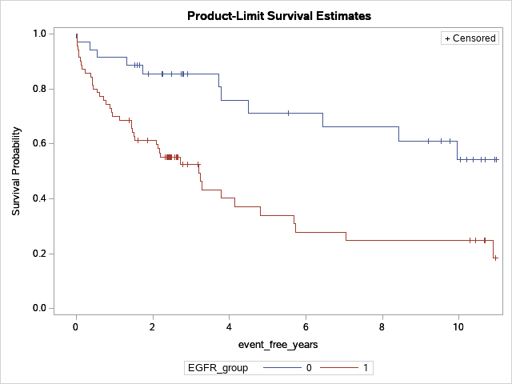